# Getting Started with Tidymodels

Luca Baggi

# Load the libraries:

```r
# Main framework
library(tidymodels)

# Helper packages
library(readr)       # for importing data
library(broom.mixed) # for converting bayesian models to tidy tibbles
library(dotwhisker)  # for visualizing regression results
```

And set the seed;

```r
set.seed(42)
```

# Load the data

```r
urchins <- read_csv("https://tidymodels.org/start/models/urchins.csv") %>%
  # Change the columns names to be a little more verbose
  setNames(c("food_regime", "initial_volume", "width")) %>%
  # Factors are very helpful for modeling, so we convert one column
  mutate(food_regime = factor(food_regime, levels = c("Initial", "Low", "High")))
```

Let’s use `prop.table()` to show the ratios of the observations per `food_regime`:

```r
table(urchins$food_regime) %>% prop.table()
```

```
  Initial       Low      High
0.3333333 0.3333333 0.3333333
```

This is lucky, but it happens because the data has been purposefully created.

# Visualisations

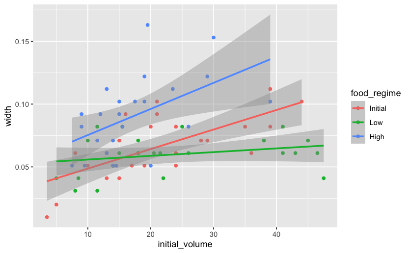

We leave the confidence intervals (CI) as they indicate where the estimate is distorted by a lack of data in a specific region. Still, it is clear that there might be a pattern for classification!

# Model fitting

No data pre-processing is done in this tutorial; we will predict a new value outside of this dataset.

We define our linear model:

```r
lm_urchins <- linear_reg() %>%
  set_engine('lm') %>%
  fit(width ~ initial_volume * food_regime, data = urchins) %>%

lm_urchins %>% tidy()
```

```
Error in lm_urchins(.) : could not find function "lm_urchins"
```

And then visualise it in the `tidy` format:

| term | estimate | std.error | statistic | p.value |
| --- | --- | --- | --- | --- |
| (Intercept) | 0.0331216259 | 0.0096186287 | 3.4434873 | 0.0010020308 |
| initial_volume | 0.0015546403 | 0.0003978337 | 3.9077643 | 0.0002220426 |
| food_regimeLow | 0.0197823628 | 0.0129883393 | 1.5230864 | 0.1325144691 |
| food_regimeHigh | 0.0214111044 | 0.0145317736 | 1.4733993 | 0.1453969848 |
| initial_volume:food_regimeLow | -0.0012593696 | 0.0005101652 | -2.4685525 | 0.0161637663 |
| initial_volume:food_regimeHigh | 0.0005253946 | 0.0007019580 | 0.7484702 | 0.4568356317 |

Also, note that the regression automatically adds the base terms and plots the coefficients for each level interaction.

## Better visualise the outcomes of the regression

This step is needed to generate a dot-and-whisker plot with `dwplot`. The vanilla command prints red elements. We can tweak it to make them a different colour. However, we can add a vertical line to indicate the zero level.

```
Ignoring unknown parameters: lintype
```

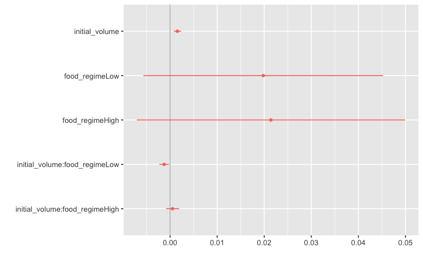

```r
lm_urchins %>% tidy() %>%
  dwplot(
    vline = geom_vline(xintercept = 0, colour = 'grey', lintype = 2)
  )
```

This signals that the only statistically significant variable is the initial volume and the interaction with the `low` food regime: all of the others cross the 0 boundary, so they are not different from zero at the 95% significance level.

# Model predictions

Let’s create some new points:

```r
# expand.grid() is a base function that creates a dataframe out of the inputs' combinations.
new_points <- expand.grid(initial_volume = 20,
                          food_regime = c('Initial', 'Low', 'High',))
```

```
Error in c("Initial", "Low", "High", ) : argument 4 is empty
```

And see what comes out (a tibble):

| initial_volume | food_regime |
| --- | --- |
| 20 | Initial |
| 20 | Low |
| 20 | High |

To make a prediction, let’s get back to our model, `lm_urchins`, and apply it to the predictions with the `predict()` command. The command returns a tibble. **It has the same size as the `new_points` tibble, so we can bind the new columns to it!**.

| .pred | initial_volume | food_regime |
| --- | --- | --- |
| 0.06421443 | 20 | Initial |
| 0.05880940 | 20 | Low |
| 0.09613343 | 20 | High |

We can also use the model to compute the predicted confidence intervals and bind them to the tibble of the predicted results!

| .pred_lower | .pred_upper | .pred | initial_volume | food_regime |
| --- | --- | --- | --- | --- |
| 0.05549934 | 0.07292952 | 0.06421443 | 20 | Initial |
| 0.04986251 | 0.06775629 | 0.05880940 | 20 | Low |
| 0.08696233 | 0.10530453 | 0.09613343 | 20 | High |

[output not shown]

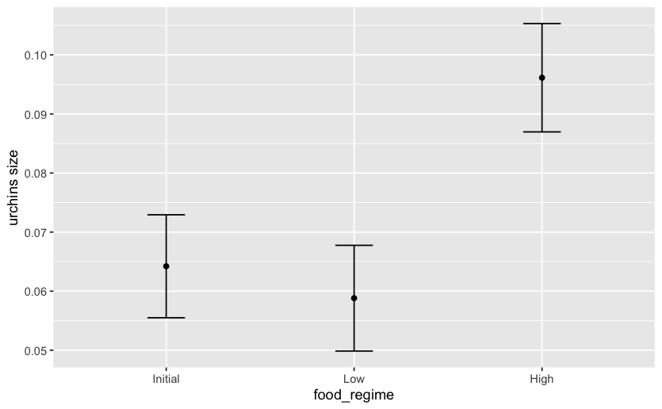

# Using a different engine

We can use `stan` to create a bayesian linear model. We need to specify the `prior` distribution of the parameter (recall, this is the main difference between frequentist and bayesian analysis). We are given a Cauchy distribution, which is simply a t with one degree of freedom.

```r
library(rstanarm)
```

```
Error in library(rstanarm) : there is no package called ‘rstanarm’
```

```r
param_distribution = rstanarm::student_t(df = 1)
```

```
Error in loadNamespace(name) : there is no package called ‘rstanarm’
```